```python
import matplotlib.pylab as plt
import numpy as np
import pandas as pd
```

# ------------------------------------- 1 -------------------------------------

In this part of the exercise, I generalized the backpropagation function to include the possibility of using a hidden layer. Finally, I validated the results over the domain x:[-1, 1] and y:[-1, 1] by generating a grid of points and visualizing the decision boundaries. This approach demonstrates how the network can successfully distinguish between classes in a circularly distributed dataset.

```python
# Define sigmod function
def sigmoid(z):
    return 1 / (1 + np.exp(-z))

# Define the derivate of the sigmoid function
def d_sigmoid(z):
    return sigmoid(z) * (1 - sigmoid(z))
```

```python
# Define backpropagation function with a hidden layer
def backprop(X, y, h=5, epochs=500, eta=0.1):
    """
    Trains a 1-hidden-layer MLP (with h neurons) using backpropagation.

    Parameters:
    -----------
    X : array of shape (n_samples, n_features)
        Input data.
    y : array of shape (n_samples,)
        Binary labels in {0, 1}.
    h : int
        Number of neurons in the hidden layer.
    epochs : int
        Number of training epochs.
    eta : float
        Learning rate.

    Returns:
    --------
    W1, b1, W2, b2 : ndarrays
        Trained weights and biases for the hidden and output layers.
    errors : list of floats
        Evolution of the error (loss) over epochs.
    """
    np.random.seed(43)

    n_samples, n_features = X.shape # 100, 2
    y = y.reshape(-1, 1) # 100, 1 (column vector)

    # Initialize weights
    # Hidden layer: W1 is (n_features x h), b1 is (1 x h)
    W1 = np.random.randn(n_features, h) # (2 features, 5 neurons) where h is the hidden layer
    b1 = np.random.randn(1, h) # 1 row, 5 columns; bias for each neuron

    # Output layer: W2 is (h x 1), b2 is (1 x 1)
    W2 = np.random.randn(h, 1) # 5 neurons, 1 output; from hidden layer to output layer
    b2 = np.random.randn(1, 1) # bias for output layer

    errors = []

    for epoch in range(epochs):
        # ---- Forward Pass ----
        z1 = np.dot(X, W1) + b1
        a1 = sigmoid(z1) # activation of hidden layer

        z2 = np.dot(a1, W2) + b2
        a2 = sigmoid(z2) # activation of output layer

        # Cost function: MSE
        error = np.mean((a2 - y) ** 2)
        errors.append(error)

        # ---- Backward Pass (Backpropagation) ----
        dE_dz2 = (a2 - y) * d_sigmoid(z2) # error gradient

        dE_da1 = dE_dz2.dot(W2.T) # hidden layer contribution to the error
        dE_dz1 = dE_da1 * d_sigmoid(z1)

        # Update weights
        dW2 = np.dot(a1.T, dE_dz2)
        db2 = np.sum(dE_dz2, axis=0, keepdims=True)

        dW1 = np.dot(X.T, dE_dz1)
        db1 = np.sum(dE_dz1, axis=0, keepdims=True)

        W2 -= eta * dW2
        b2 -= eta * db2
        W1 -= eta * dW1
        b1 -= eta * db1

    return W1, b1, W2, b2, errors
```

```python
# Read the circular dataset
circular_data = pd.read_csv('circle.csv', header=None, names=['x1', 'x2', 'y'])
zeros = np.where(circular_data['y'] == 0)[0]
ones = np.where(circular_data['y'] == 1)[0]
print(circular_data.shape)
print(circular_data.head(5))
```

```
(100, 3)
         x1        x2  y
0 -0.971935  0.846927  0
1 -0.552995 -0.576830  0
2 -0.094904 -0.298862  1
3 -0.809564  0.856891  0
4  0.399009  0.690462  0
```

```python
X = circular_data[['x1', 'x2']].values
y = circular_data['y'].values.reshape(len(circular_data['y'].values), 1)
```

```python
print("X : ", X.shape)
print("y : ", y.shape)
```

```
X :  (100, 2)
y :  (100, 1)
```

```python
W1, b1, W2, b2, errors = backprop(X, y)
```

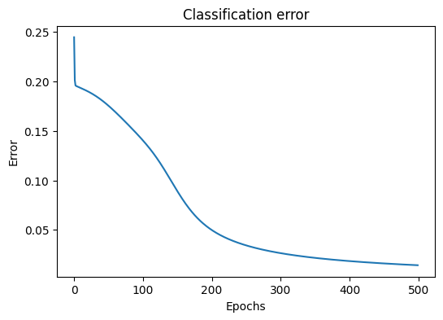

```python
# Plot the error convergence
plt.figure(figsize=[6, 4])
plt.plot(errors)
plt.xlabel('Epochs')
plt.ylabel('Error')
plt.title('Classification error')
plt.show()
```

```python
# Final error
final_error = errors[-1]
print(f"Final error: {final_error:.2f}")
```

```
Final error: 0.01
```

This plot shows the classification error of the model over 500 training epochs. At the beginning, the error is relatively high, indicating that the network is not yet accurate in its predictions. As training progresses, the error steadily decreases reaching **0.01**, reflecting the model’s improved ability to separate the classes. By the final epochs, the error reaches a lower, more stable value, suggesting that the training process is converging and the network is effectively learning the classification task.

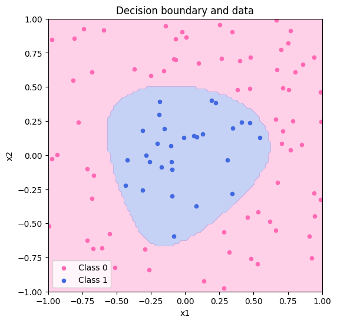

```python
grid_x = np.linspace(-1, 1, 100)
grid_y = np.linspace(-1, 1, 100)
XX, YY = np.meshgrid(grid_x, grid_y)
grid_points = np.c_[XX.ravel(), YY.ravel()]

# Forward pass on the grid to predict class probabilities
z1_grid = np.dot(grid_points, W1) + b1
a1_grid = sigmoid(z1_grid)
z2_grid = np.dot(a1_grid, W2) + b2
a2_grid = sigmoid(z2_grid)

preds = (a2_grid >= 0.5).astype(int).reshape(XX.shape)

# Plot the decision boundary and the original data
plt.figure(figsize=(6, 6))
plt.contourf(XX, YY, preds.reshape(XX.shape), levels=[0, 0.5, 1], alpha=0.3, colors=['hotpink', 'royalblue'])
plt.scatter(circular_data['x1'][zeros], circular_data['x2'][zeros], color='hotpink', s=20, label='Class 0')
plt.scatter(circular_data['x1'][ones], circular_data['x2'][ones], color='royalblue', s=20, label='Class 1')
plt.title("Decision boundary and data")
plt.xlabel("x1")
plt.ylabel("x2")
plt.legend()
plt.show()
```

In this plot, the decision boundary generated by the trained model is shown as different colored regions: pink for Class 0 and blue for Class 1. The individual data points are overlaid on the plot, with pink dots representing Class 0 and blue dots representing Class 1. This visualization demonstrates how the network has learned to separate the two classes. The boundary encircles the region of Class 1 data, indicating that the model can successfully distinguish between the circular distribution of points.

# ------------------------------------- 2 -------------------------------------

**Hyperparameter Tuning via Grid Search**

In this code block, I perform a grid search over two hyperparameters:

- The number of neurons in the hidden layer (`h`).
- The learning rate (`eta`).

For each combination of `h` and `eta`, I train the network for a fixed number of epochs (1000) and record the final training error. I keep track of the best (lowest) error seen so far and update the “best configuration” accordingly. By iterating through all possible parameter pairs, I identify the optimal setup (in terms of minimal final error) for the model.

```python
h_values = [5, 10, 15, 20]  # number of neurons in the hidden layer
eta_values = [0.001, 0.01, 0.1, 0.5]  # learning rates

# 2D array to store the final error for each (h, eta)
errors_grid = np.zeros((len(h_values), len(eta_values)))

best_error = float('inf')
best_h = None
best_eta = None

for i, h in enumerate(h_values):
    for j, eta in enumerate(eta_values):
        # Train the network with the current parameters
        W1, b1, W2, b2, errors = backprop(X, y, h=h, epochs=1000, eta=eta)

        # Perform the forward pass on the training data to obtain predictions
        z1_train = np.dot(X, W1) + b1
        a1_train = sigmoid(z1_train)
        z2_train = np.dot(a1_train, W2) + b2
        a2_train = sigmoid(z2_train)

        # Get final error
        final_error = errors[-1]
        print(f"h = {h}, eta = {eta}, Error = {final_error:.4f}")

        # Store in our grid
        errors_grid[i, j] = final_error

        # Track best parameters
        if final_error < best_error:
            best_error = final_error
            best_h = h
            best_eta = eta
```

```
h = 5, eta = 0.001, Error = 0.1932
h = 5, eta = 0.01, Error = 0.1397
h = 5, eta = 0.1, Error = 0.0064
h = 5, eta = 0.5, Error = 0.0009
h = 10, eta = 0.001, Error = 0.1993
h = 10, eta = 0.01, Error = 0.0960
h = 10, eta = 0.1, Error = 0.0060
h = 10, eta = 0.5, Error = 0.2900
h = 15, eta = 0.001, Error = 0.2033
h = 15, eta = 0.01, Error = 0.1434
h = 15, eta = 0.1, Error = 0.0072
h = 15, eta = 0.5, Error = 0.2900
h = 20, eta = 0.001, Error = 0.2000
h = 20, eta = 0.01, Error = 0.0863
h = 20, eta = 0.1, Error = 0.0072
h = 20, eta = 0.5, Error = 0.2900
```

```python
print("Best configuration found:")
print(f"h = {best_h}, eta = {best_eta}, Error = {best_error:.4f}")
```

```
Best configuration found:
h = 5, eta = 0.5, Error = 0.0009
```

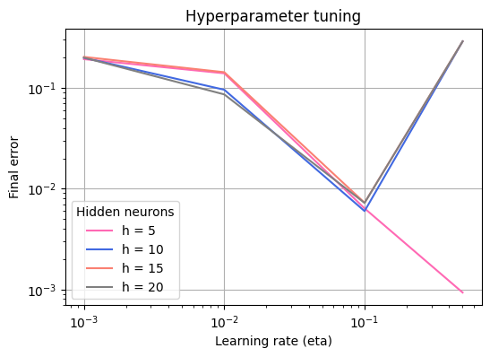

```python
# Define the colors for each hidden layer size
colors = ["hotpink", "royalblue", "salmon", "gray"]

# Plotting the final error as a function of the learning rate for each hidden layer size
plt.figure(figsize=(6, 4))
for i, h in enumerate(h_values):
    plt.plot(eta_values, errors_grid[i, :], label=f'h = {h}', color=colors[i])

plt.xlabel('Learning rate (eta)')
plt.ylabel('Final error')
plt.title('Hyperparameter tuning')
plt.legend(title='Hidden neurons')
plt.xscale('log')
plt.yscale('log')
plt.grid(True)
plt.show()
```

This plot shows the final error after training the model for each combination of hidden neurons (`h`) and learning rate (`eta`)). The x-axis displays the learning rate and the y-axis shows the final training error, both on a logarithmic scale. Each line corresponds to a different number of hidden neurons (5, 10, 15, and 20).

From the plot, we see that the configuration with `h` **= 5** and `eta` **= 0.5** achieves the lowest final error of **0.0009**. This indicates that, for this particular problem, a smaller hidden layer combined with a relatively large learning rate performs best among the tested setups.

# ------------------------------------- 3 -------------------------------------

This function trains a single-hidden-layer MLP using backpropagation with momentum. For each epoch, it performs a forward pass to compute the output and error, then a backward pass to compute gradients, and finally updates the weights and biases by adding a momentum term. The function returns the trained parameters and the error history over all epochs. The momentum term helps speed up convergence and avoid getting stuck in local minima.

```python
def backprop(X, y, h=5, epochs=500, eta=0.1, momentum=0.9):
    """
    Trains a single hidden-layer MLP (with h neurons) using backpropagation with momentum.

    Parameters:
    -----------
    X : array of shape (n_samples, n_features)
        Input data.
    y : array of shape (n_samples,)
        Binary labels in {0, 1}.
    h : int
        Number of neurons in the hidden layer.
    epochs : int
        Number of training epochs.
    eta : float
        Learning rate.
    momentum : float
        Momentum coefficient.

    Returns:
    --------
    W1, b1, W2, b2 : arrays
        Trained weights and biases for the hidden and output layers.
    errors : list of floats
        Evolution of the error (loss) over epochs.
    """
    np.random.seed(43)

    n_samples, n_features = X.shape
    y = y.reshape(-1, 1)

    # Initialize weights and biases
    W1 = np.random.randn(n_features, h)
    b1 = np.random.randn(1, h)
    W2 = np.random.randn(h, 1)
    b2 = np.random.randn(1, 1)

    # Initialize velocity terms (for momentum) to zeros
    V_W1 = np.zeros_like(W1)
    V_b1 = np.zeros_like(b1)
    V_W2 = np.zeros_like(W2)
    V_b2 = np.zeros_like(b2)

    errors = []

    for epoch in range(epochs):
        # ---- Forward Pass ----
        z1 = np.dot(X, W1) + b1
        a1 = sigmoid(z1)
        z2 = np.dot(a1, W2) + b2
        a2 = sigmoid(z2)

        # Compute the error (Mean Squared Error)
        error = np.mean((a2 - y) ** 2)
        errors.append(error)

        # ---- Backward Pass (Backpropagation) ----
        dE_dz2 = (a2 - y) * d_sigmoid(z2)
        dE_da1 = np.dot(dE_dz2, W2.T)
        dE_dz1 = dE_da1 * d_sigmoid(z1)

        dW2 = np.dot(a1.T, dE_dz2)
        db2 = np.sum(dE_dz2, axis=0, keepdims=True)

        dW1 = np.dot(X.T, dE_dz1)
        db1 = np.sum(dE_dz1, axis=0, keepdims=True)

        # ---- Update with Momentum ----
        V_W2 = momentum * V_W2 - eta * dW2
        V_b2 = momentum * V_b2 - eta * db2
        V_W1 = momentum * V_W1 - eta * dW1
        V_b1 = momentum * V_b1 - eta * db1

        W2 += V_W2
        b2 += V_b2
        W1 += V_W1
        b1 += V_b1

    return W1, b1, W2, b2, errors
```

```python
W1, b1, W2, b2, errors = backprop(X, y)
```

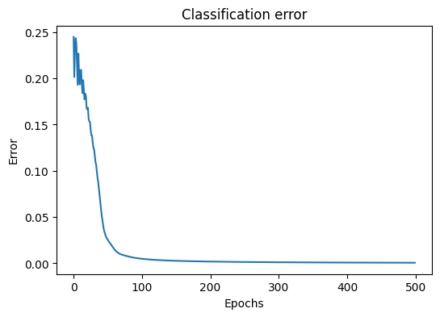

```python
# Plot the error convergence
plt.figure(figsize=[6, 4])
plt.plot(errors)
plt.xlabel('Epochs')
plt.ylabel('Error')
plt.title('Classification error')
plt.show()
```

```python
# Final error
final_error = errors[-1]
print(f"Final error: {final_error:.4f}")
```

```
Final error: 0.0006
```

This plot shows how the classification error decreases over 500 epochs. Initially, the error is around 0.25, but it rapidly declines and stabilizes near zero by about the 100th epoch. The final error of **0.0006** indicates that the model has learned to classify the data almost perfectly.

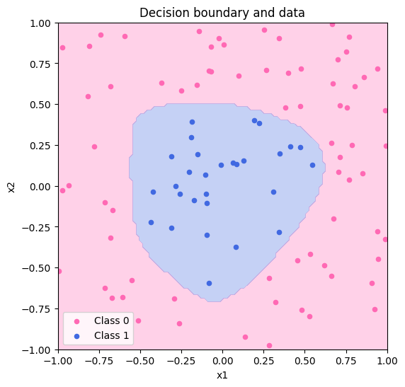

```python
grid_x = np.linspace(-1, 1, 100)
grid_y = np.linspace(-1, 1, 100)
XX, YY = np.meshgrid(grid_x, grid_y)
grid_points = np.c_[XX.ravel(), YY.ravel()]

# Forward pass on the grid to predict class probabilities
z1_grid = np.dot(grid_points, W1) + b1
a1_grid = sigmoid(z1_grid)
z2_grid = np.dot(a1_grid, W2) + b2
a2_grid = sigmoid(z2_grid)

# Classification: assign class 1 if probability >= 0.5
preds = (a2_grid >= 0.5).astype(int).reshape(XX.shape)

# Plot the decision boundary and the original data
plt.figure(figsize=(6, 6))
plt.contourf(XX, YY, preds.reshape(XX.shape), levels=[0, 0.5, 1], alpha=0.3, colors=['hotpink', 'royalblue'])
plt.scatter(circular_data['x1'][zeros], circular_data['x2'][zeros], color='hotpink', s=20, label='Class 0')
plt.scatter(circular_data['x1'][ones], circular_data['x2'][ones], color='royalblue', s=20, label='Class 1')
plt.title("Decision boundary and data")
plt.xlabel("x1")
plt.ylabel("x2")
plt.legend()
plt.show()
```

As in section 1, this plot shows the decision boundary learned by the model. The pink region corresponds to Class 0, and the blue region corresponds to Class 1. Each dot represents a data point, colored according to its true class. The figure illustrates how the network separates the two classes in the input space, with the boundary enclosing most of the Class 1 points.

Both versions of the backpropagation function (with and without momentum) yield good results. However, the final error improves from **0.01** (without momentum) to **0.0006** when momentum is included, indicating that the momentum-based approach converges more effectively.

# ------------------------------------- 4 -------------------------------------

In this section, I define a function that trains a multi-layer perceptron by randomly initializing the network’s weights and biases, then applying backpropagation with momentum. At each epoch, I propagate inputs forward to compute the output and error, then propagate gradients backward to update the weights and biases.

```python
def backprop_random(a, b, hidden_layers=[5], epochs=1000, eta=0.01, momentum=0.9):
    """
    Trains a multi-layer perceptron using random weight initialization and backpropagation with momentum.

    Parameters:
        a (np.ndarray): Input data of shape (input_neurons, number of samples).
        b (np.ndarray): Target output data of shape (output_neurons, number of samples).
        hidden_layers (list): List specifying the number of neurons in each hidden layer.
        epochs (int): Number of training iterations.
        eta (float): Learning rate.
        momentum (float): Momentum factor for weight updates.

    Returns:
        error_list (list): List containing the mean squared error for each epoch.
        weights (list): List of weight matrices for each layer.
        biases (list): List of bias vectors for each layer.
    """
    input_neurons = np.shape(a)[0]
    output_neurons = np.shape(b)[0]

    # Initialize weights and biases
    layer_sizes = [input_neurons] + hidden_layers + [output_neurons]
    weights = [np.random.uniform(low=-1, high=1, size=(layer_sizes[i+1], layer_sizes[i]))
               for i in range(len(layer_sizes)-1)]
    biases = [np.random.uniform(low=-1, high=1, size=(size, 1)) for size in layer_sizes[1:]]

    # Initialize momentum deltas
    v_weights = [np.zeros(w.shape) for w in weights]
    v_biases = [np.zeros(b.shape) for b in biases]

    error_list = []

    for i in range(epochs):
        # Forward propagation
        net_inputs = [np.dot(weights[0], a) + biases[0]]
        outputs = [sigmoid(net_inputs[0])]
        for j in range(1, len(weights)):
            net_inputs.append(np.dot(weights[j], outputs[j-1]) + biases[j])
            outputs.append(sigmoid(net_inputs[j]))

        # Compute output error
        error = outputs[-1] - b
        error_list.append(np.mean(error**2))

        # Backpropagation
        delta = [error * d_sigmoid(net_inputs[-1])]
        for j in range(len(weights) - 2, -1, -1):
            delta.insert(0, np.dot(weights[j + 1].T, delta[0]) * d_sigmoid(net_inputs[j]))

        # Compute gradients for weights and biases
        w_delta = [np.dot(delta[0], a.T)]
        b_delta = [np.sum(delta[0], axis=1, keepdims=True)]
        for j in range(1, len(weights)):
            w_delta.append(np.dot(delta[j], outputs[j - 1].T))
            b_delta.append(np.sum(delta[j], axis=1, keepdims=True))

        # Update weights and biases with momentum
        for j in range(len(weights)):
            v_weights[j] = momentum * v_weights[j] + eta * w_delta[j]
            weights[j] -= v_weights[j]
            v_biases[j] = momentum * v_biases[j] + eta * b_delta[j]
            biases[j] -= v_biases[j]

    return error_list, weights, biases
```

```python
# Read the spiral dataset
spiral_data = pd.read_csv('spiral.csv', names=['x1', 'x2', 'y'])
zeros = np.where(spiral_data['y'] == 0)[0]
ones = np.where(spiral_data['y'] == 1)[0]
```

```python
# Apply the backprop_random function
a = spiral_data[['x1', 'x2']].T.values
b = spiral_data['y'].values.reshape(1, len(spiral_data['y'].values))
error, weights, biases = backprop_random(a, b, hidden_layers=[5, 3])
```

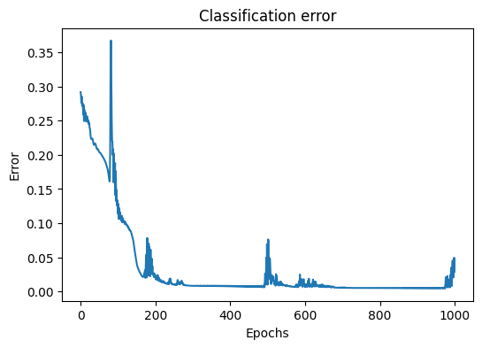

```python
# Plot the error convergence
plt.figure(figsize=[6, 4])
plt.plot(error)
plt.xlabel('Epochs')
plt.ylabel('Error')
plt.title('Classification error')
plt.show()
```

```python
# Final error
final_error = error[-1]
print(f"Final error: {final_error:.3f}")
```

```
Final error: 0.029
```

```python
# Validate results over the domain x: [-1, 1], y: [-1, 1]
x_range = np.linspace(-1, 1, 100)
y_range = np.linspace(-1, 1, 100)
xx, yy = np.meshgrid(x_range, y_range)
grid = np.c_[xx.ravel(), yy.ravel()].T

# Forward propagation on the grid
net_inputs = [np.dot(weights[0], grid) + biases[0]]
outputs = [sigmoid(net_inputs[0])]
for j in range(1, len(weights)):
    net_inputs.append(np.dot(weights[j], outputs[j-1]) + biases[j])
    outputs.append(sigmoid(net_inputs[j]))
```

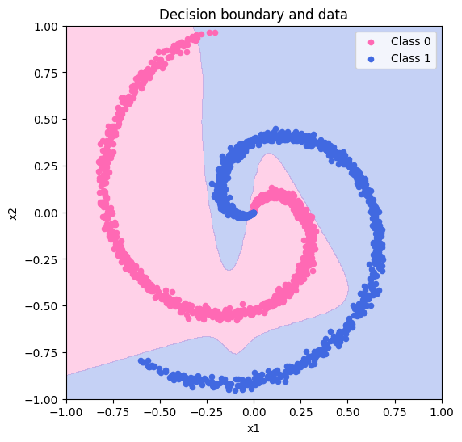

```python
# Plot the decision boundary and data points
plt.figure(figsize=[6, 6])
plt.contourf(xx, yy, outputs[-1].reshape(xx.shape), levels=[0, 0.5, 1], alpha=0.3, colors=['hotpink', 'royalblue'])
plt.scatter(spiral_data['x1'][zeros], spiral_data['x2'][zeros], color='hotpink', s=20, label='Class 0')
plt.scatter(spiral_data['x1'][ones], spiral_data['x2'][ones], color='royalblue', s=20, label='Class 1')
plt.xlabel('x1')
plt.ylabel('x2')
plt.title('Decision boundary and data')
plt.legend()
plt.show()
```

This plot illustrates the decision boundary learned by the model on the spiral dataset. The pink region corresponds to Class 0 and the blue region corresponds to Class 1. The model successfully captures the complex spiral separation, classifying the two spirals into distinct regions.

Momentum-based backpropagation functions generally perform better when run multiple times because momentum helps to avoid local minima and stabilizes weight updates, leading to more effective convergence. However, the outcomes still depend on random weight initialization and other factors. In the case of spiral classification, the final error tends to be higher due to the inherent complexity of constructing a decision boundary that accurately separates the two spiral classes. Additionally, in the latest session, I increased the number of epochs to 1000 and decreased the learning rate (eta) to 0.01 because, with the previous settings, the error did not converge properly. These adjustments have resulted in improved convergence of the model.